# Rasool01519545_CW2

### Task 1.2.3 [^]

Discussion for task 1.2.3

CNN with dropout has 100,000 parameters (approx) whereas the MLP has almost 1 million parameters. Even so, the CNN has the same accuracy and loss as that of the MLP model. This shows that the CNN model is significantly more efficient than the MLP.

Observed differences:

The CNN droput model has a faster convergence rate than the MLP model. Is slightly more bumpier than the MLP model (MLP is more smooth).

### Task 1.2.4 [^]

In this task, we choose one image from the test set and use imshow() to visualise the image and one feature map of our choice from each convolutional layer of the architecture in 1.2.2 and comment on the features extracted by each of the layers.

Here we define the first image, which we will use.

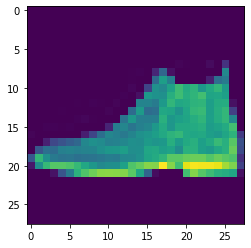

```python
pixels = x_test_CNN[0] # choose an image
plt.imshow(pixels)
plt.show()
```

```python
# This shows a summary of the model, which we can use to obtian the names of the layers
optimal_drop_rate_model.summary()
```

```
Model: "sequential_29"
_________________________________________________________________
 Layer (type)                Output Shape              Param #
=================================================================
 conv2d_120 (Conv2D)         (None, 26, 26, 8)         80

 conv2d_121 (Conv2D)         (None, 24, 24, 8)         584

 conv2d_122 (Conv2D)         (None, 22, 22, 16)        1168

 conv2d_123 (Conv2D)         (None, 20, 20, 16)        2320

 max_pooling2d_30 (MaxPoolin  (None, 10, 10, 16)       0
 g2D)

 flatten_30 (Flatten)        (None, 1600)              0

 dense_59 (Dense)            (None, 64)                102464

 dropout_26 (Dropout)        (None, 64)                0

 dense_60 (Dense)            (None, 10)                650

=================================================================
Total params: 107,266
Trainable params: 107,266
Non-trainable params: 0
_________________________________________________________________
```

```python
from tensorflow.keras.models import Model

# Obtain inputs from the model
inputs = optimal_drop_rate_model.inputs

# The names of the convoloutional layers
layer_names = ['conv2d_120', 'conv2d_121', 'conv2d_122', 'conv2d_123', 'max_pooling2d_30']
# obtain outputs from the model from each layer
outputs = [optimal_drop_rate_model.get_layer(layer_name).output for layer_name in layer_names] # add .output at the end
# obtain the features of each layer
optimal_drop_rate_model_features = Model(inputs=inputs, outputs=outputs)
```

```python
# Checking the inputs and outputs at each layer
optimal_drop_rate_model_features.inputs # inputs, then inputs,
optimal_drop_rate_model_features.outputs
```

```
[<KerasTensor: shape=(None, 26, 26, 8) dtype=float32 (created by layer 'conv2d_120')>,
 <KerasTensor: shape=(None, 24, 24, 8) dtype=float32 (created by layer 'conv2d_121')>,
 <KerasTensor: shape=(None, 22, 22, 16) dtype=float32 (created by layer 'conv2d_122')>,
 <KerasTensor: shape=(None, 20, 20, 16) dtype=float32 (created by layer 'conv2d_123')>,
 <KerasTensor: shape=(None, 10, 10, 16) dtype=float32 (created by layer 'max_pooling2d_30')>]
```

```python
# For the image obtain the feastures
features = optimal_drop_rate_model_features(pixels[tf.newaxis, ...])
features = [pixels] + features
```

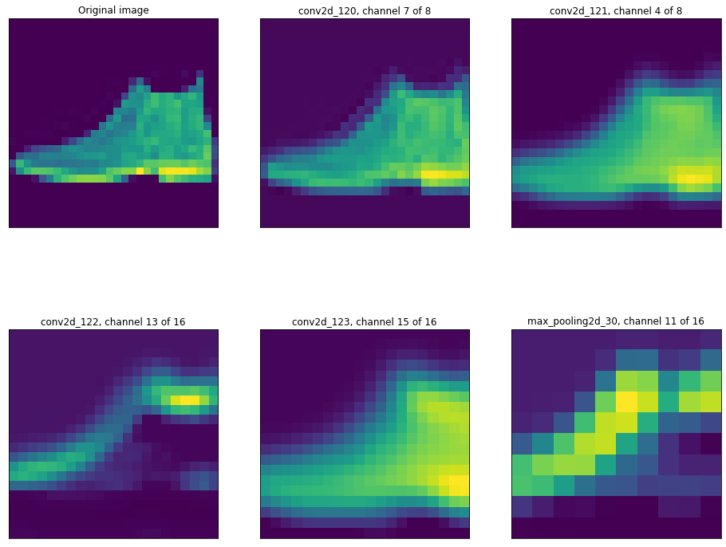

```python
# Here we create figures for each convoloutional layer and we plot one feature map for each conv layer
n_rows, n_cols = 2, 3
fig, axes = plt.subplots(n_rows, n_cols, figsize=(16, 14))
fig.subplots_adjust(hspace=0.05, wspace=0.2)
image = pixels

# iterate through the number of features
for i in range(len(features)):
    # Select the feature map
    feature_map = features[i]
    num_channels = feature_map.shape[-1]
    row = i // n_cols
    col = i % n_cols

    # Orignal image plot
    if i == 0:
        axes[row, col].imshow(image)
        axes[row, col].set_title('Original image')
    else:
        # select a random feature
        random_feature = np.random.choice(num_channels)
        axes[row, col].imshow(feature_map[0, ..., random_feature])
        axes[row, col].set_title('{}, channel {} of {}'.format(layer_names[i-1], random_feature + 1, num_channels))

    axes[row, col].get_xaxis().set_visible(False)
    axes[row, col].get_yaxis().set_visible(False)
plt.show()
```

Discussion: The deeper we go into the model the more abstract the features become. This is evident as we see in the original image a clear picture of a shoe. In the first convolutional layer, the image becomes blurry and abstract features are beginning to be extracted., This trend continues as we increase the number of Conv layers. The final image shows a max pooling layer and how the dimensions are reduced.

# Task 2: Unsupervised learning ^

## 2.1 Dimensionality reduction and clustering of a subset of the Fashion-MNIST image data ^

In this task we consider the first N = 1000 images found in the Fashion-MNIST data set used in the task above and perform dimensionality reduction and clustering of a subset of the Fashion-MNIST image data.

### Task 2.1.1 [^]

In this task, we utilise only NumPy and ScipPy to normalise and centre the data and then perform PCA ( Principal Component Analysis) to carry out dimensionality reduction on this subset data.

PCA is a spectral linear method, where the dimensionality of the samples is very large (p >>1) in our case p = 784, and we may want to reduce the number of dimensions and try to represent the data in a lower dimension.

We aim for a description of every data point in terms of a basis function $\theta_j$:

$x_i = ∑_{j = 1}^p a_j^i\theta_j$

and we search for an orthonormal basis such that

$ θ^T_j .θ_k = δ_{jk}$.

With these we can obtain the coefficcients $a_j^i$ mentioned above as projections on the basis: $ a_j^i = \theta^T_j . x^i $.

To utilise PCA effectively we have to pre-process the data as part of Feature Scaling. To do this we; convert integer 8 encoding of pixels to a floating-point number between 0 and 1 and then subtract from each image the mean and scale the dimension of each image by $1/σ$ where $𝞂$ is the standard deviation.

This is then followed by the implementaion of PCA. Here we assume that we are performing PCA on some dataset $\boldsymbol X$ for $k$ principal components. We then need to perform the following steps, which we break into parts:

1. Compute the covariance matrix $\mathbf C = \mathbf X^\top \mathbf X/(n-1)$
2. Find eigenvalues and corresponding eigenvectors for the covariance matrix, $\mathbf C = \mathbf V \mathbf L \mathbf V^\top,$
3. Sort by the largest eigenvalues and the corresponding eigenvectors.
4. Compute the projection onto the spaced spanned by the top $n$ eigenvectors.

First we create a subset of the data and reshape it to the correct dimentions.

```python
# Create subset of the data
(x_train_un, y_train_un) = x_train_nn[:1000], y_train_nn[:1000]
# reshape data to correct dimensions
x_train_un = x_train_un.reshape(-1,28*28)
```

The figure below shows that pixel values converted to floating point number between 0 and 1.

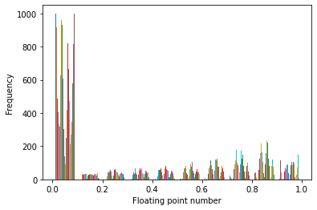

```python
# Figure showing an histogram of sample data with scaling
plt.hist(x_train_un[0:,])
plt.xlabel("Floating point number")
plt.ylabel("Frequency")
plt.show()
```

Normalizing and centering is performed below.

```python
def normalize(X):
    """
    X: array of values

    returns:
    xbar, normalized data

    This function takes an input array of data and normalises and centres the data.
    """
    mu = np.mean(X, axis=0) # obtain the mean
    std = np.std(X, axis=0) # standard deviation
    std_filled = std.copy()
    std_filled[std==0] = 1.
    Xbar = ((X-mu)/std_filled) # normalising
    return Xbar
```

```python
# Normalize the data
x_train_un = normalize(x_train_un)
```

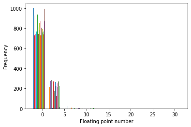

```python
# Figure showing an histogram of sample data with normalizing and centering
plt.hist(x_train_un[0:,])
plt.xlabel("Floating point number")
plt.ylabel("Frequency")
plt.show()
```

Having scaled and centred the data we now create the PCA function based on the algorithm described above.

```python
def pca_function(X,m):
    """
    X: array of shape N x P
    m: integer, number of principal components

    returns:
    X_pca: projection of the data onto a new dimension, N x m
    eigenvector: eigenvectors of projection P x m
    eigenvalues: eigenvalues of projection m,

    This function performs PCA (principal component analysis) to reduce the
    number of dimensions of a given matrix.


    """

    # create covariance matrix S
    C = 1.0/(len(X)-1) * np.dot(X.T, X)


    # compute eigenvalues and eigenvectors using the eigsh scipy function
    eigenvalues, eigenvectors = linalg.eigsh(C, m, which="LM", return_eigenvectors=True)

    # sorting the eigenvectors and eigenvalues from largest to smallest eigenvalue
    sorted_index = np.argsort(eigenvalues)[::-1]
    eigenvalues=eigenvalues[sorted_index]
    eigenvectors=eigenvectors[:,sorted_index ]

    # transform our data
    X_pca = X.dot(eigenvectors)

    return X_pca, eigenvectors, eigenvalues
```

### Task 2.1.2 [^]

In this task, we compute the top m = 25 principal components and plot the corresponding eigenvalues and the fraction of variance explained as m is increased. We then comment on what the optimal value m should be.

Define a function which obtains the explained variance.

```python
def explained_var_func(X, eigenvectors, eigenvalues):
    """
    X: matrix of size N x m
    eigenvector: Matrix of size P x m
    eigenvalues: Matrix of size m,

    returns
    explained_variancess: an array of size m

    This function computes the explained variance for each principal component
    """

    C = 1.0/(len(X)-1) * np.dot(X.T, X)
    all_eigenvalues, _ = np.linalg.eig(C)
    total_variance = abs(all_eigenvalues.sum())

    explained_variances = eigenvalues /  total_variance
    return explained_variances
```

We utilise the function pca_function to compute the projection, eigenvectors and eigenvalues for m = 25 principal components.

```python
# choose our number of principle components
m = 25
# compute the projection, the eigenvector and eigenvalues from our function
X_pca_25, eigenvectors_25, eigenvalues_25 = pca_function(x_train_un,m)
```

```python
# Compute the explained variances based on the function above
explained_variances = explained_var_func(X_pca_25, eigenvectors_25, eigenvalues_25)
```

Below I plot the corresponding eigenvlaues to the principal components.

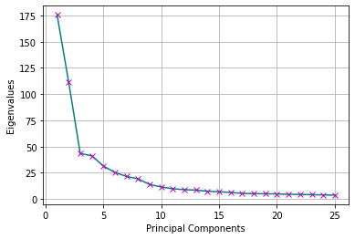

```python
# Plot eigenvalues
m_vals = np.arange(1,26,1)
plt.plot(m_vals, eigenvalues_25, color = 'teal')
plt.plot(m_vals, eigenvalues_25, marker = 'x', color = 'm', ls= ' ')
plt.grid()
plt.xlabel("Principal Components")
plt.ylabel("Eigenvalues")
plt.show()
```

Below I plot the explained variance as a function of m.

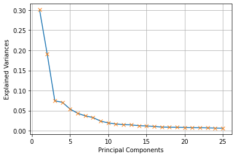

```python
# Plot explained variance
m_vals = np.arange(1,26,1)
plt.plot(m_vals, explained_variances)
plt.plot(m_vals, explained_variances, marker = 'x', ls= ' ')
plt.grid()
plt.xlabel("Principal Components")
plt.ylabel("Explained Variances")
plt.show()
```

Discussion for task 2.1.2

The two figures have similar plots, just different y-axis scaling as one is a percentage (explained variance) whereas the other is a value. The optimal value for the number of principal components is two. This is because the value after two provides significantly less contribution to the total variance.

Optimal value = 2

### Task 2.1.3 [^]

In this task we consider the top m = 2 principal components and produce a plot of the N = 1000 data in the PCA space spanned by these m = 2 components, colouring them according to their class image.

```python
# choose our number of principle components
m = 2

# compute the projection, the eigenvector and eigenvalues from our function
X_pca_2, eigenvectors_2, eigenvalues_2 = pca_function(x_train_un,m)
```

Plot the data in the PCA space

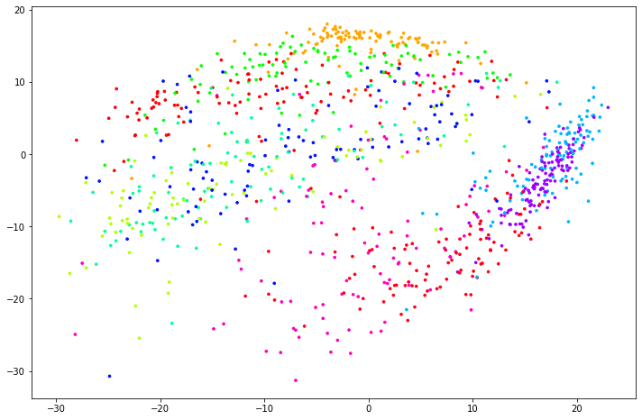

```python
# Plot scatter graph of the PCA space
plt.figure(figsize=(12,8))
plt.scatter(X_pca_2[:,0],X_pca_2[:,1], c = y_val, cmap= 'hsv',s = 7)
plt.show()
```

Discussion for task 2.1.3:

We can observe on the scatter plot that there are 10 clusters (10 different colours) however there is significant overlap between the clusters. Although some clusters such as pink and light blue have more dense regions they still overlap.

This means that our k-means clustering algorithm in the next task may not perform well as there are no clear boundaries between the clusters.

From the figure what I see is that there are two dense regions and if we had no preconceived notion of how many clusters there were then the two regions could be classed as a cluster each (two in total so most clusters would be in one or the other).

### Task 2.1.4 [^]

In this task, we consider the data points described by top m = 2 principal components of PCA and apply k-means to cluster the points, varying k in the k-means algorithm between 2 and 10.

In the k-means algorithm we want to find a hard assignment between N samples and k clusters.

The algorithm: 1) Start with data points $x^i$ and a distance measure (Euclidean): $D = || x^i - x^j||^2$.

We then have a within distance:

$W(c) = \frac{1}{2}∑_{l = 1}^k∑|| x^i - x^j||^2$

2) With a given number of clusters k, assign every sample to one of the k clusters at random.

3) We then compute the centroid of each of the k clusters using:

$m_l = \frac{1}{|c_l|}∑x^i$ for l = 1,...,k.

4) We then reaasign each $x^i$ to the closest centroid.

5) We then iterate through steps 1 and 2 until convergence is met, as in W(c) does not improve much.

We first define a function that creates initial centroids of our clusters.Done by randomly assigning labels such thhat a given group fo data points belong to a cluster.

```python
def centroid_func(X, k):
    """
    X: matrix of size N x m
    k: integer specifying number of clusters

    Returns
    Initial cluster centroid positions, k x m
    labs: Initial labels

    This function returns an initial position of each clusters centroid.
    """

    n_samples, n_features = X.shape


    # labels: assign every sample to a cluster at random
    np.random.seed(42)
    labels = np.random.randint(low=0, high=k, size=n_samples)
    X_labels = np.append(X, labels.reshape(-1,1), axis=1)

    # computing the centroids of each of the k clusters
    centroids = np.zeros((k, n_features))
    for i in range(k):
        centroids[i] = np.mean([x for x in X_labels if x[-1]==i], axis=0)[0:2]

    return centroids, labels
```

We utilise the initial centroids to now iterate over a number of iterations to relabel our data points to the closest centroid.

We also introduce an algorithm called Elbow method which be calculated within the function to find the closest cnetroids.

This is a method for determing the optimal number of clusters for a given data set. We calcualte the Within-Cluster-Sum of Sqaured Errors (WSS) and choose th k value for which WSS srtarts to first diminish. We use the Euclidean distance metric to calcualte the distance of a sample point from its predicted cluster centre and sum the sqaure of these for all points.

The optimal cluster number will be where an albow shape appears in the results.

```python
def cluster_assignment(X,k,max_iter = 50):
    """
    X: matrix of N x m
    k: integer specifying number of clusters
    max_iter: integer for maximum number of iterations

    return:
    centroids: updated centroids matrix of size k x m
    wss_score: the WSS score for k clusters

    This function updates the inital random centroids passed finds the optimal
    cluster centroids and the assignments of data points to those clusters.


    """
    centroids, labels = centroid_func(X, k)
    new_labels = np.zeros(len(X))
    difference = 0

    wss_score = []
    # k-means algorithm
    for i in range(max_iter):

        # distances: between data points and centroids
        distances = np.array([np.linalg.norm(X - c, axis=1) for c in centroids])
        # new_labels: computed by finding centroid with minimal distance
        new_labels = np.argmin(distances, axis=0)

        if (labels==new_labels).all():
            # labels unchanged
            labels = new_labels
            print('Labels unchanged! Terminating k-means for K: ',k )
            for c in range(k):
                res = np.power(X[labels==c] - centroids[c],2).sum() # compute distance
                wss_score.append(res)
            break
        else:
            # labels changed
            # difference: percentage of changed labels
            difference = np.mean(labels!=new_labels)

            labels = new_labels
            for c in range(k):
                # update centroids by taking the mean over associated data points
                if (labels == c).any():
                    centroids[c] = np.mean(X[labels==c], axis=0)

    return centroids, labels , np.sum(wss_score)
```

We define a WSS score function that will return the WSS score for each number of clusters.

```python
def WSS_score(X,k_range,max_iter = 50):
    """
    X: matrix of N x m
    k_range: array of ints specifying number of clusters
    max_iter: integer for maximum number of iterations

    return:

    wss_val: Array of ints for each value in k_range

    This function utilises cluster_assignment function to find the WSS
    scorefor each number of clusters.

    """
    WSS_val = [] # create empty list
    for i in k_range:
        centroids,labels, val = cluster_assignment(X,i,max_iter = 50) # cluster assignment for specific k
        WSS_val.append(val) # append results
    return WSS_val
```

We initialise paramters as required for the task and use the WSS_score function to plot how the WSS score changes as a function of number of clusters.

```python
# Initialise k range
k_range = np.arange(2,11,1)
```

```python
# Run the algorithm to obtain the WSS score values for the different k values
WSS_vals = WSS_score(X_pca_2,k_range,max_iter = 50)
```

```
Labels unchanged! Terminating k-means for K:  2
Labels unchanged! Terminating k-means for K:  3
Labels unchanged! Terminating k-means for K:  4
Labels unchanged! Terminating k-means for K:  5
Labels unchanged! Terminating k-means for K:  6
Labels unchanged! Terminating k-means for K:  7
Labels unchanged! Terminating k-means for K:  8
Labels unchanged! Terminating k-means for K:  9
Labels unchanged! Terminating k-means for K:  10
```

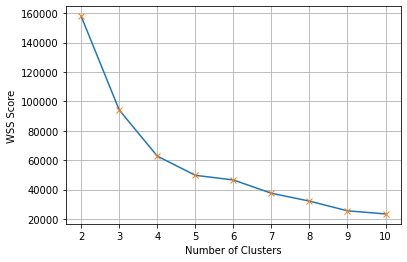

```python
# Plot the WSS_scores
plt.plot(k_range, WSS_vals)
plt.plot(k_range, WSS_vals, marker = 'x', ls= ' ')
plt.xlabel("Number of Clusters")
plt.ylabel("WSS Score")
plt.grid()
plt.show()
```

We visualise the optimal number of clusters below.

```python
# First obtain the centroids or labels
centroids, labels, wss_val = cluster_assignment(X_pca_2,4,max_iter = 50)
```

```
Labels unchanged! Terminating k-means for K:  4
```

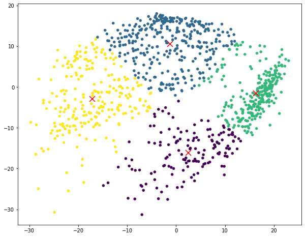

```python
# Plot the results the optimal  cluster number of around 4.
plt.figure(figsize=(10,8))
plt.scatter(X_pca_2[:,0], X_pca_2[:,1], c=labels, s = 20, );
plt.scatter(centroids[:, 0], centroids[:, 1], c='red', marker='x', s=120);
```

Discussion for task 2.1.4:

As per the elbow method, the optimal value for k would be where we notice the elbow on the plot. What we see in the figure is that there is no clear elbow instead it is ambiguous between 3,4 and 5. I believe that the optimal value for k = 4.

Therefore the optimal number for k is not equal to 10.

## 2.2 Clustering of the feature matrix ^

As part of the next parts of Task 2, we work with another data set from a social network of bottlenose dolphins. This is a study of a group of 62 bottlenose dolphins and their behaviours. Each row in the dataset corresponds to one of the N = 62 bottlenose dolphins in the network. We have three sources of information:

1. Set of features characterising each individual. This is given as a N x p feature matrix F, where N = 62 samples with p = 32 features capturing different traits of the dolphins.
2. Social network of associations between the individual dolphins. N = 62 nodes of the graph are the individuals and the E = 159 edges correspond to the frequent association between them. This information is given as a N x N adjacency matrix, A.
3. The table listing dolphin names is ordered according to the rows of the feature and the adjacency matrices.

In this Subtask, we will analyse the feature matrix F containing the characteristics of the dolphins.

### Data Loading- Matrix F

In this section we import the Feature Matrix and perform some checks.

```python
# Load the feature Matrix and the dolphin names
feature_matrix = np.load('dolphins_F_62x32(1).npy')
dolphin_names = pd.read_csv('dolphin_names.csv')
```

```python
# Create a pandas frame of the feature matrix and visualise
pandas_feature_matrix = pd.DataFrame(feature_matrix)
pandas_feature_matrix.head()
```

|  | 0 | 1 | 2 | 3 | 4 | 5 | 6 | 7 | 8 | 9 | ... | 22 | 23 | 24 | 25 | 26 | 27 | 28 | 29 | 30 | 31 |
| --- | --- | --- | --- | --- | --- | --- | --- | --- | --- | --- | --- | --- | --- | --- | --- | --- | --- | --- | --- | --- | --- |
| 0 | -0.695456 | -0.175504 | 0.559717 | 0.423152 | -0.340293 | 0.237454 | 0.253204 | 0.189686 | 0.112683 | 0.594460 | ... | 0.449620 | -0.151111 | -0.143445 | 0.434180 | -0.308412 | 0.086365 | -0.107450 | -0.703641 | 0.332740 | 0.606755 |
| 1 | 0.032124 | -0.147836 | 0.404154 | -0.045095 | -0.050370 | -0.509280 | 0.583647 | 0.489127 | 0.103776 | -0.101660 | ... | 0.824583 | 0.078373 | 0.311201 | 0.004980 | 0.195476 | -0.325984 | 0.053203 | -0.131443 | -0.066457 | 0.028816 |
| 2 | -0.466298 | -0.310222 | 0.797716 | 0.419497 | -0.031842 | 0.042536 | 0.038176 | 0.428967 | 0.623526 | 0.519616 | ... | 0.232563 | 0.318118 | 0.219167 | 0.557517 | -0.620058 | -0.733322 | -0.678331 | -0.114187 | 0.418441 | -0.241562 |
| 3 | -0.396057 | -0.571269 | 0.494241 | 0.175312 | -0.044562 | 0.224739 | 0.068630 | 0.076584 | -0.158037 | -0.057705 | ... | 0.281842 | -0.144960 | 0.082379 | 0.961370 | -0.263572 | 0.202262 | -0.583811 | 0.002948 | -0.576619 | 0.436467 |
| 4 | -0.174839 | -0.357261 | 0.504786 | 0.727213 | 0.302937 | 0.600257 | 0.910726 | 0.113001 | 0.129434 | -0.618385 | ... | -0.059240 | -0.222439 | 0.418005 | 0.502354 | -0.528199 | -0.680188 | -0.057558 | -0.386826 | -0.073863 | 0.436142 |

5 rows × 32 columns

```python
# Visualise the dolphin names
dolphin_names = dolphin_names.drop('Unnamed: 0', 1)
dolphin_names.head()
```

|  | name |
| --- | --- |
| 0 | Beak |
| 1 | Beescratch |
| 2 | Bumper |
| 3 | CCL |
| 4 | Cross |

```python
# Combine the two pandas frame to see the name of the dolphin in combination with its features
pandas_feature_matrix = dolphin_names.join(pandas_feature_matrix[0:31])
pandas_feature_matrix.head()
```

|  | name | 0 | 1 | 2 | 3 | 4 | 5 | 6 | 7 | 8 | ... | 22 | 23 | 24 | 25 | 26 | 27 | 28 | 29 | 30 | 31 |
| --- | --- | --- | --- | --- | --- | --- | --- | --- | --- | --- | --- | --- | --- | --- | --- | --- | --- | --- | --- | --- | --- |
| 0 | Beak | -0.695456 | -0.175504 | 0.559717 | 0.423152 | -0.340293 | 0.237454 | 0.253204 | 0.189686 | 0.112683 | ... | 0.449620 | -0.151111 | -0.143445 | 0.434180 | -0.308412 | 0.086365 | -0.107450 | -0.703641 | 0.332740 | 0.606755 |
| 1 | Beescratch | 0.032124 | -0.147836 | 0.404154 | -0.045095 | -0.050370 | -0.509280 | 0.583647 | 0.489127 | 0.103776 | ... | 0.824583 | 0.078373 | 0.311201 | 0.004980 | 0.195476 | -0.325984 | 0.053203 | -0.131443 | -0.066457 | 0.028816 |
| 2 | Bumper | -0.466298 | -0.310222 | 0.797716 | 0.419497 | -0.031842 | 0.042536 | 0.038176 | 0.428967 | 0.623526 | ... | 0.232563 | 0.318118 | 0.219167 | 0.557517 | -0.620058 | -0.733322 | -0.678331 | -0.114187 | 0.418441 | -0.241562 |
| 3 | CCL | -0.396057 | -0.571269 | 0.494241 | 0.175312 | -0.044562 | 0.224739 | 0.068630 | 0.076584 | -0.158037 | ... | 0.281842 | -0.144960 | 0.082379 | 0.961370 | -0.263572 | 0.202262 | -0.583811 | 0.002948 | -0.576619 | 0.436467 |
| 4 | Cross | -0.174839 | -0.357261 | 0.504786 | 0.727213 | 0.302937 | 0.600257 | 0.910726 | 0.113001 | 0.129434 | ... | -0.059240 | -0.222439 | 0.418005 | 0.502354 | -0.528199 | -0.680188 | -0.057558 | -0.386826 | -0.073863 | 0.436142 |

5 rows × 33 columns

To visualise the training data, we utilise a heatmap plot which plots the correlation between each variable.

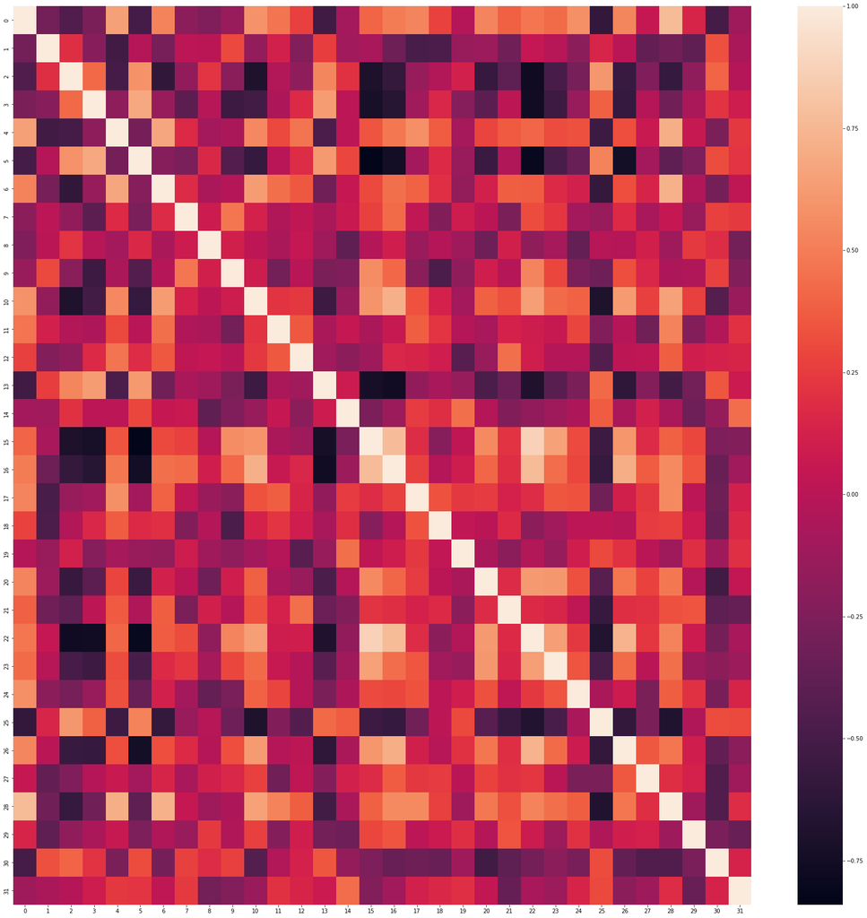

```python
plt.figure(figsize = (30, 30))
sns.heatmap(pandas_feature_matrix.corr(),  annot = False)
plt.show()
```

What we can see is that some features have a strong correlation between each such as 3 and 5. However a significant proportion of the features seem to have little or no correlation. We can see some features are inversely correlated such as 0 and 30 or 20 and 30.

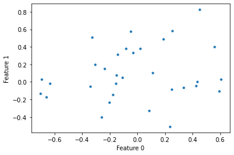

```python
# Plot a scatter graph of first two features
plt.scatter(feature_matrix[0], feature_matrix[1] , s =10)
plt.xlabel("Feature 0")
plt.ylabel("Feature 1")
plt.show()
```

### Task 2.2.1 [^]

In this task using we employ heirarchical clustering to cluster the feature matrix F. We utilise average linkage and take Euclidean distance as our distance mtric. We then report the sequence of clusters from finest to coarsest.

In Hierarchical clustering analysis, we represent the whole data set as a binary tree, called a dendrogram, where the N leaves at the bottom are samples and the root at the top is the whole data set.

Each bifurcation of the tree corresponds to a merger of two groups of samples.

Agglomerative schemes for hierarchical clustering: We start from each sample in its cluster, the algorithm proceeds to merge samples into clusters of successive coarseness to finally arrive at the whole data set. The aim is to reduce the number of clusters one-by-one from N down to 1. We will be using the average linkage as a criterion that decides the merger.

$d_{GA}(G,H) =\frac{1}{N_GH_H}∑D_{ij} $ where H and G are two clusters we are considering. This essentially computes the distance between clusters as an average overall pair of points and uses the distance between all parts of clusters to decide on the next merger.

We first define a pariwise distance function that finds the euclidean distance between each point.

```python
def pairwise_distances(points):
    '''
    Args:
        points: A numpy array of points having the shape (N, D),
          where N is the number of points and D is the number of features.
    Returns:
        A numpy array with shape (N, N) such that the element (i, j) is the computed
        distance between i-t
        h point and j-th point in X.
    '''
    N, D = points.shape
    distance = np.empty((N, N))

    # distance matrix will be symmetric, so avoid redundant computations.
    for i in range(N):
        distance[i, i] = 0
        for j in range(i + 1, N):
            d = np.sqrt(np.power(points[i, :] - points[j, :], 2).sum())    ## <-- EDIT THIS LINE
            distance[i, j] = d
            distance[j, i] = d

    return distance
```

We define the average linkage funciton as described above, to be used in the algorithm.

```python
def average_linkage(distances, cluster_assignment, i, j):
    """
    This function computes the average linkage value between two clusters.
    Args:
      distances: A numpy array of pair-wise distances for the given points.
      cluster_assignment: A 1-D numpy array that assigns a cluster id for every point.
      i: the first cluster id.
      j: the second cluster id.
    Returns:
      The average distance between the two given clusters.
    """
    # Select the point indices of the first cluster.
    points_i = np.argwhere(cluster_assignment == i)
    # Select the point indices of the second cluster.
    points_j = np.argwhere(cluster_assignment == j)
    # Form a cartesian product between the indices in i and indices in j.
    pairs = np.array([[element_i.item(), element_j.item()]  for element_i in points_i for element_j in points_j])
    # Select the pair distances between the points in the two clusters from the distances matrix.
    pairs_distance = distances[pairs[:, 0], pairs[:, 1]]
    # Return the average
    return pairs_distance.mean()
```

Define hierarchical clustering algorithm, which utilises thhe distance matrix and the specified linkage (average).

```python
def hierarchical_clustering(points, distances, linkage):
    """
    The hierarchical clustering algorithm start with every point as a single cluster and
    each iteration merges two clusters into one. We may wish to store all the
    intermediate clustering results with respect to the number of clusters left.

    Args:
     points: A numpy array of points having the shape (N, D),
          where N is the number of points and D is the number of features.
     distances: A numpy array with shape (N, N) such that the element (i, j) is the computed
        distance between i-th point and j-th point in X.
     linkage: A linkage function from the above to call to compute the linkage values between two clusters.

    Returns:
     A numpy array of shape (N, N) of which each row stores the clustering assignment at each level.
     The first row, i.e. a[0, :], represents the highest level of clustering where all columns have the same index value.
     The second row, i.e. a[1, :], represents all the points assigned into two cluster indices.
     The last row, i.e. a[N - 1, :], represents the points assigned into N - 1 cluster indices.
    """
    N, D = points.shape
    assignments = np.zeros((N, N))

    # Begin with every point is its own cluster
    current_assignment = np.arange(N)

    # The id to be assigned for the next merged cluster
    next_cluster_id = N

    # Begin from level (N - 1) to level 1
    for level in range(N - 1, 0, -1):
        if (level % 10) == 0:
            print(f'level:{level}')
        cluster_ids = np.unique(current_assignment)

        min_d = np.inf

        # Initialize the cluster ids to be merged in this iteration.
        cluster_a, cluster_b = (-1, -1)

        # Now find the two clusters that have the minimum distance in between.
        for i in range(cluster_ids.size):
            for j in range(i + 1, cluster_ids.size):
                cluster_i = cluster_ids[i]
                cluster_j = cluster_ids[j]
                d = linkage(distances, current_assignment, cluster_i, cluster_j) # perform linkage
                if d < min_d: # if distance less than smallest distance
                    min_d = d
                    cluster_a, cluster_b = (cluster_i, cluster_j) # assign cluster


        # Merge the two clusters
        current_assignment[(current_assignment == cluster_a) | (current_assignment == cluster_b)] = next_cluster_id
        next_cluster_id += 1
        # Store the current cluster assignment into the assignments array.
        assignments[level, :] = current_assignment

    return assignments
```

We need to initialise the apramters needed for heirarchical clustering, which requries the distance matrix.

```python
# Compute the distance matrix
distance_matrix = pairwise_distances(feature_matrix)
```

Here we visualise the distance matrix

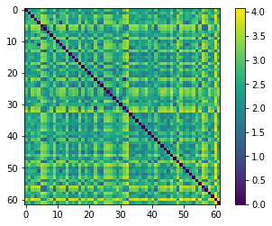

```python
# plot a heatmap of the distance matrix
plt.imshow(distance_matrix)
plt.colorbar();
```

Perform heirarchical clustering as requried per the task.

```python
# Run the algorithm to find clusters
hierarchical_clusters = hierarchical_clustering(feature_matrix, distance_matrix,average_linkage)
```

```
level:60
level:50
level:40
level:30
level:20
level:10
```

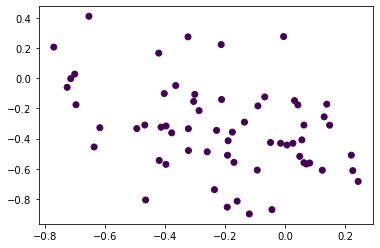

```python
# A scatter graph of two features
plt.scatter(feature_matrix[:,0], feature_matrix[:,1], c=hierarchical_clusters[1,:]);
```

We now visualise the hierarchical clusters produced for the first two features for each coarseness level as a scatter plot, with colours representing the cluster it has been assigned to.

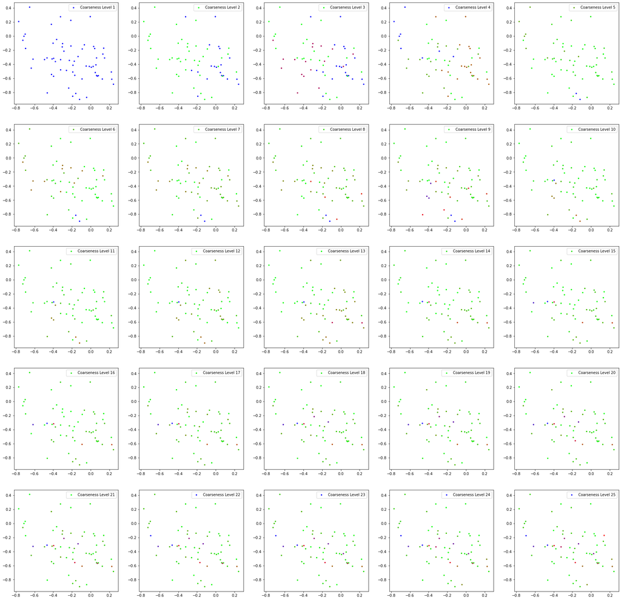

```python
fig, axes = plt.subplots(5, 5, figsize=(30, 30))
counter = 0
for i in range(5):
    for j in range(5):
        counter += 1
        # print(counter)
        axes[i,j].scatter(feature_matrix[:,0], feature_matrix[:,1], c=hierarchical_clusters[counter,:], cmap = 'brg',s = 7, label = "Coarseness Level " + str(counter))
        axes[i,j].legend()
```

The figure shows clustering for the first 25 levels. It is shown clearly as we decrease the level the number of clusters decrease, as expected of the algorithm.

We create a dendogram below using hierarchical clustering with scipy to visualise the the levels.

```python
Z = hierarchy.linkage(feature_matrix, method='average', metric='euclidean', optimal_ordering=False)
```

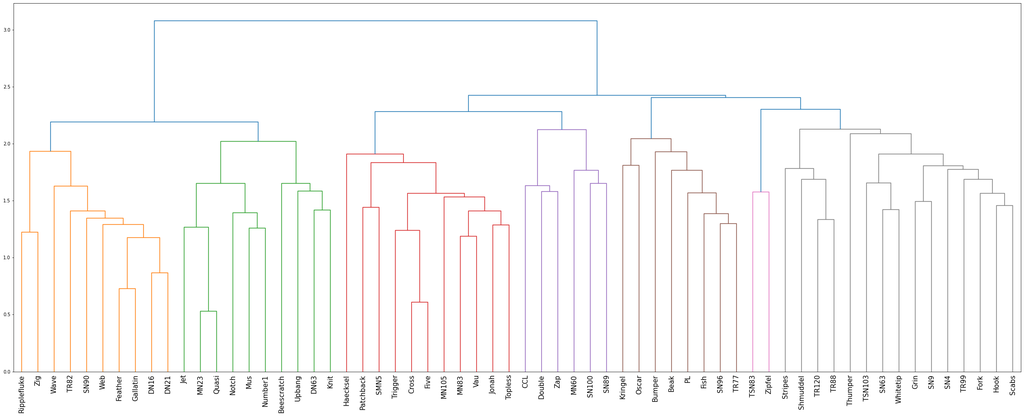

```python
# PLot a dendogram
fig,axes = plt.subplots(1,1,figsize = (40,15))

dolpin_num = np.squeeze(dolphin_names.to_numpy())
dw1 = hierarchy.dendrogram(Z)
indicies = [index.get_text() for index in axes.get_xticklabels()]
dolphins = []
for i in indicies:
    dolphins.append(dolpin_num[int(i)])
axes.set_xticklabels(dolphins)

plt.xticks(size = 15)
plt.show()
```

The figure (dendogram) shows the clustering levels with the assosiated dolphin.

### Task 2.2.2 [^]

In this task, we implement a function to calculate the Silhouette Score of a given clustering. The Silhouette Score is a measure of the quality of clustering and is defined as the mean Silhouette Coefficient over all samples, where the Silhouette Coefficient of a given sample is;

Silhouette Coefficient $= \frac{d_2 - d_1}{max(d_1,d_2)}$ where $d_1$ is the average distance bertween the sample and the points in its cluster, and $d_2$ is the avreage distancec between the sample and th epoints in the nearest clsuter.

The optimal level for clustering is the one which maximises the Silhouette Score.

We first define function distance 1 which computes d1 as mentioned above.

```python
def distance_1(level, dist_mat,samp):
    """
    level: N x 1 An array which has the clusters for a specific level
    dist_mat: N x N distance matrix iof each point from one another
    samp: integer which d1 needs to be computed for

    returns:
    d1: integer

    This function computes the d1 value for the specific sample.

    """
    indicies = np.array(np.where(level == level[samp])) # find indicies of in cluster points
    indicies = indicies.ravel()
    distance_in_cluster = dist_mat[samp][indicies] # find distances from points in cluster
    distance_in_cluster = distance_in_cluster[distance_in_cluster> 0 ] # dont count the point with itself
    d1 = np.mean(distance_in_cluster) # find mean distance
    return d1
```

Below we define distance 2 matrix, which computes d2 as required for above.

```python
def distance_2(level, dist_mat, samp):
    """
    level: N x 1 An array which has the clusters for a specific level
    dist_mat: N x N distance matrix iof each point from one another
    samp: integer which d2 needs to be computed for

    returns:
    d2: integer

    This function computes the d2 value for the specific sample and finds the closest matrix.

    """
    uniq = np.unique(level) # find all unique clusters
    d2 = np.inf # set initial distance to infinity

    for clust in uniq:
        if level[samp] != clust: # for clusters that are not the same
            indicies_other = np.array(np.where(level == clust)) # find indicies of other points in clsuter
            indicies_other = indicies_other.ravel()
            distance_out_cluster = dist_mat[samp][ indicies_other] # get distances to each point
            average_dist = np.mean(distance_out_cluster) # find the average distance of points in the other cluster
            if average_dist < d2 : # if this cluster is closer
                d2 = average_dist

    return d2
```

Define a Silhouette Score function, which returns the silhouette score the the assignment matrtix.

```python
def silhoute_score(heir_clust, dist_mat):
    """
    heir_clust: N X N matrix which contains assignments
    dist_mat: N x N distance matrix

    return:
    sil_sco: Returns the silhouette score for each level as an array

    This function computes the silhouette score for each level from the assignment
    matrix.
    """
    sil_sco = []
    for j in range(2,len(heir_clust)):

        level = heir_clust[j,:]
        sil_coeff = []
        for i in range(len(level)):

            indicies = np.array(np.where(level == level[i]))
            indicies = indicies.ravel()
            if len(indicies) > 1:

                d1 = distance_1(level, dist_mat, i)
                d2  = distance_2(level,dist_mat, i )

                coef = (d2-d1)/np.max([d1, d2])
                sil_coeff.append(coef)
            else:

                sil_coeff.append(0)

        sil_sco.append(np.mean(sil_coeff))

    return(sil_sco)
```

Compute the Silhouette score for the assignment matrix found in task 2.2.1

```python
# Compute the Silhouette score values for each level
silhouette_score_values = silhoute_score(hierarchical_clusters, distance_matrix)
```

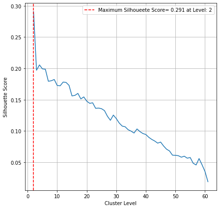

```python
# Plot the Silhouette Score for each level
levels = np.arange(2,62,1)
plt.figure(figsize = (7,7))
plt.plot(levels, silhouette_score_values)

plt.axvline(x = levels[np.argmax(silhouette_score_values)],color = 'r',ls = '--',  label =
            "Maximum Silhoueete Score= "+str(round(np.max(silhouette_score_values), 3))
            +" at Level: "+str(levels[np.argmax(silhouette_score_values)]))
plt.grid()
plt.legend()
plt.xlabel("Cluster Level")
plt.ylabel("Silhouette Score")
plt.show()
```

The best silhouette score is the maximum silhouette score out of all the cluster levels. As reported by the figure above, the optimal level is level 2.